# Bellabeat Case Study

Blake Meschke

2022-10-27

## Installing and loading common packages and libraries

Here is a list below of the packages in used for this Project.

```r
library(dplyr)
library(tidyverse)
```

```r
library(fs)
library(ggplot2)
library(lubridate)
```

## Introduction and background

Bellabeat is a high-tech/health focused company that creates health-focused products for women. For this project, I analyzed The ‘FitBit Fitness Tracker Data’. From this data, I gained insight on how consumers use their smart devices.This enabled me to give useful suggestions to help Bellabeat make wise decisions with their future smart products.

## Upload your CSV files to R

```r
dailyActivity_merged <- read.csv(file = 'dailyActivity_merged.csv')
dailyCalories_merged<- read.csv(file="dailyCalories_merged.csv")
dailyIntensities_merged<- read.csv(file="dailyIntensities_merged.csv")
dailySteps_merged<- read.csv(file="dailySteps_merged.csv")
heartrate_seconds_merged<- read.csv(file="heartrate_seconds_merged.csv")
hourlyCalories_merged<- read.csv(file="hourlyCalories_merged.csv")
hourlyIntensities_merged<- read.csv(file="hourlyIntensities_merged.csv")
hourlySteps_merged<- read.csv(file="hourlySteps_merged.csv")
minuteCaloriesNarrow_merged<- read.csv(file="minuteCaloriesNarrow_merged.csv")
minuteCaloriesWide_merged<- read.csv(file="minuteCaloriesWide_merged.csv")
minuteIntensitiesNarrow_merged<- read.csv(file="minuteIntensitiesNarrow_merged.csv")
minuteIntensitiesWide_merged<- read.csv(file="minuteIntensitiesWide_merged.csv")
minuteMETsNarrow_merged<- read.csv(file="minuteMETsNarrow_merged.csv")
minuteSleep_merged<- read.csv(file="minuteSleep_merged.csv")
minuteStepsNarrow_merged<- read.csv(file="minuteStepsNarrow_merged.csv")
minuteStepsWide_merged<- read.csv(file="minuteStepsWide_merged.csv")
sleepDay_merged<- read.csv(file="sleepDay_merged.csv")
weightLogInfo_merged<- read.csv(file="weightLogInfo_merged.csv")
```

## Exploring a few key tables

The Tables we will be running analysis on that have the most information are as follows. I renamed them out of simplicity.

```r
dailyact<-dailyActivity_merged
heartsec<-heartrate_seconds_merged
hourstep<-hourlySteps_merged
sleepday<-sleepDay_merged
weight<-weightLogInfo_merged
```

## Cleaning data

From here we can see that most datasets have 0 NA values in all of our datasets, except weight, which has 65 NA values. Looking at the weight data set, all the NA values were in the Fat column. Therefore I decided to remove that column. Also, heartsec and sleepday have some duplicated data.

```r
sum(is.na(dailyact))
```

```
## [1] 0
```

```r
sum(is.na(heartsec))
```

```
## [1] 0
```

```r
sum(is.na(hourstep))
```

```
## [1] 0
```

```r
sum(is.na(sleepday))
```

```
## [1] 0
```

```r
sum(is.na(weight))
```

```
## [1] 65
```

```r
sum(is.na(dailyCalories_merged))
```

```
## [1] 0
```

```r
sum(is.na(dailyIntensities_merged))
```

```
## [1] 0
```

```r
sum(is.na(dailySteps_merged))
```

```
## [1] 0
```

```r
sum(is.na(hourlyCalories_merged))
```

```
## [1] 0
```

```r
sum(is.na(hourlyIntensities_merged))
```

```
## [1] 0
```

```r
sum(is.na(hourlySteps_merged))
```

```
## [1] 0
```

```r
sum(is.na(minuteCaloriesNarrow_merged))
```

```
## [1] 0
```

```r
sum(is.na(minuteCaloriesWide_merged))
```

```
## [1] 0
```

```r
sum(is.na(minuteIntensitiesNarrow_merged))
```

```
## [1] 0
```

```r
sum(is.na(minuteIntensitiesWide_merged))
```

```
## [1] 0
```

```r
sum(is.na(minuteMETsNarrow_merged))
```

```
## [1] 0
```

```r
sum(is.na(minuteSleep_merged))
```

```
## [1] 0
```

```r
sum(is.na(minuteStepsNarrow_merged))
```

```
## [1] 0
```

```r
sum(is.na(minuteStepsWide_merged))
```

```
## [1] 0
```

```r
# removing the fat column in the weight dataset
weight<-subset(weight, select=-Fat)
#

sum(duplicated(dailyact))
```

```
## [1] 0
```

```r
sum(duplicated(heartsec))
```

```
## [1] 482220
```

```r
sum(duplicated(hourstep))
```

```
## [1] 0
```

```r
sum(duplicated(sleepday))
```

```
## [1] 3
```

```r
sum(duplicated(weight))
```

```
## [1] 0
```

I will remove the duplicated data as follows from sleepday. Heartsec has a lot of duplicated data, but looking at the values in contains, it makes sense as to why you can have duplicated values, so I will not remove those values.

```r
sleepday<-sleepday[!duplicated(sleepday),]
```

Now I want to check some of the data types, especially for dates, in some of my important data sets I will be using.

```r
dailyact$ActivityDate<-as.Date(dailyact$ActivityDate,format='%m/%d/%Y')
sleepday$SleepDay<-as.Date(sleepday$SleepDay,format ='%m/%d/%Y' )
heartrate_seconds_merged$Time<-as.POSIXct(heartrate_seconds_merged$Time,format="%m/%d/%Y %H:%M")
hourlyIntensities_merged$ActivityHour<-as.POSIXct(hourlyIntensities_merged$ActivityHour,format="%m/%d/%Y %H:%M")
hourstep$ActivityHour<-as.POSIXct(hourstep$ActivityHour,format="%m/%d/%Y %H:%M")
weight$Date<-as.Date(weight$Date,format = '%m/%d/%Y')
dailyact<-rename(dailyact,Date=ActivityDate)
sleepday<-rename(sleepday, Date=SleepDay)
```

After exploring a few datasets and cleaning data, I have decided to do most of my analysis on the following Datasets. 1.dailyact 2.sleepday 3.hourstep 4.sleepday 5.weight

## BASIC summary statistics for our main tables

dailyact,sleepday ANd hourstep all had high participation while the datasets with weight and heartrate did not have as much participation.

```r
n_distinct(dailyact$Id)
```

```
## [1] 33
```

```r
n_distinct(sleepday$Id)
```

```
## [1] 24
```

```r
n_distinct(weight$Id)
```

```
## [1] 8
```

```r
n_distinct(heartsec$Id)
```

```
## [1] 7
```

```r
n_distinct(hourstep$Id)
```

```
## [1] 33
```

What are some quick summary statistics we’d want to know about each data frame?

# Dailyact

For the daily activity dataframe: we find that the mean amount of Total steps a day was 7638. When we filter out the times when a person had no steps a day, we see that the average amount of steps a day was around 8300. Looking at statistics from the different types of minutes, we see that sedentary minutes far outweighs the rest.

```r
dailyact %>%
  select(TotalSteps,
         TotalDistance,
         ) %>%
  summary()
```

```
##    TotalSteps    TotalDistance
##  Min.   :    0   Min.   : 0.000
##  1st Qu.: 3790   1st Qu.: 2.620
##  Median : 7406   Median : 5.245
##  Mean   : 7638   Mean   : 5.490
##  3rd Qu.:10727   3rd Qu.: 7.713
##  Max.   :36019   Max.   :28.030
```

```r
dailyact %>% select(TotalSteps,
         TotalDistance,
        ) %>%
  filter(TotalSteps>0) %>% summary()
```

```
##    TotalSteps    TotalDistance
##  Min.   :    4   Min.   : 0.00
##  1st Qu.: 4923   1st Qu.: 3.37
##  Median : 8053   Median : 5.59
##  Mean   : 8319   Mean   : 5.98
##  3rd Qu.:11092   3rd Qu.: 7.90
##  Max.   :36019   Max.   :28.03
```

```r
### Now I want to look at sedentary minutes, and the different types of active minutes to draw conclusions.

dailyact %>% select(SedentaryMinutes,LightlyActiveMinutes,FairlyActiveMinutes,VeryActiveMinutes) %>% summary()
```

```
##  SedentaryMinutes LightlyActiveMinutes FairlyActiveMinutes VeryActiveMinutes
##  Min.   :   0.0   Min.   :  0.0        Min.   :  0.00      Min.   :  0.00
##  1st Qu.: 729.8   1st Qu.:127.0        1st Qu.:  0.00      1st Qu.:  0.00
##  Median :1057.5   Median :199.0        Median :  6.00      Median :  4.00
##  Mean   : 991.2   Mean   :192.8        Mean   : 13.56      Mean   : 21.16
##  3rd Qu.:1229.5   3rd Qu.:264.0        3rd Qu.: 19.00      3rd Qu.: 32.00
##  Max.   :1440.0   Max.   :518.0        Max.   :143.00      Max.   :210.00
```

# Sleepday

For the sleep dataframe: we learned that the mean amount of sleep time was 419 minutes which corresponds to about 7 hours of sleep a day.

```r
sleepday %>%
  select(
  TotalMinutesAsleep,
  TotalTimeInBed) %>%
  summary()
```

```
##  TotalMinutesAsleep TotalTimeInBed
##  Min.   : 58.0      Min.   : 61.0
##  1st Qu.:361.0      1st Qu.:403.8
##  Median :432.5      Median :463.0
##  Mean   :419.2      Mean   :458.5
##  3rd Qu.:490.0      3rd Qu.:526.0
##  Max.   :796.0      Max.   :961.0
```

# Heartsec

In the heartsec dataframe, we see the average heartrate is about 77 bpm.

```r
heartsec %>% select(Value) %>% summary(mean)
```

```
##      Value
##  Min.   : 38.00
##  1st Qu.: 64.00
##  Median : 75.00
##  Mean   : 77.02
##  3rd Qu.: 87.00
##  Max.   :203.00
```

```r
heartsec %>% group_by(Id) %>% summarize(mean(Value))
```

```
## # A tibble: 7 x 2
##           Id `mean(Value)`
##        <dbl>         <dbl>
## 1 2022484408          80.2
## 2 2026352035          93.8
## 3 2347167796          76.7
## 4 4020332650          82.3
## 5 4388161847          66.1
## 6 4558609924          81.7
## 7 5553957443          62.8
```

# Hourstep

```r
hourstep$Date<-as.Date(hourstep$ActivityHour)
hourstep$Time<-format(as.POSIXct(hourstep$ActivityHour),format="%H:%M:%S")
hourstep %>% group_by(Time) %>% summarize(sum(StepTotal))
```

```
## # A tibble: 24 x 2
##    Time     `sum(StepTotal)`
##    <chr>               <int>
##  1 00:00:00            39404
##  2 01:00:00            21555
##  3 02:00:00            15964
##  4 03:00:00             5996
##  5 04:00:00            11836
##  6 05:00:00            40886
##  7 06:00:00           166191
##  8 07:00:00           284932
##  9 08:00:00           398044
## 10 09:00:00           403404
## # ... with 14 more rows
```

```r
hour_step_mean_step_by_time<-hourstep %>% group_by(Time) %>% summarize(step_total=sum(StepTotal))
is.tibble(hour_step_mean_step_by_time)
```

```
## [1] TRUE
```

```r
hour_step_mean_step_by_time2<-as.data.frame(hour_step_mean_step_by_time)
is.tibble(hour_step_mean_step_by_time2)
```

```
## [1] FALSE
```

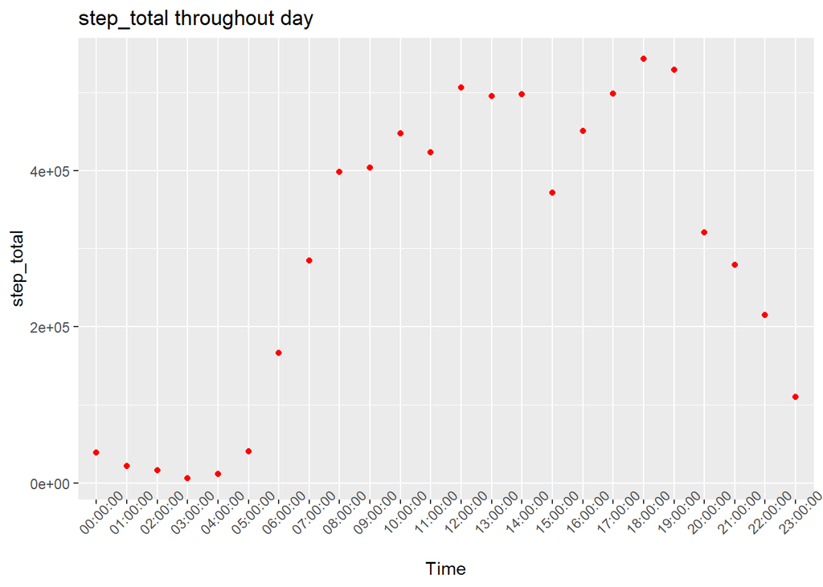

```r
ggplot(data=hour_step_mean_step_by_time2)+geom_point(mapping=aes(x=Time,y=step_total),color="red")+
labs(title= "step_total throughout day")+
theme(axis.text.x=element_text(angle=45))
```

# Weight

we see that the average weight in pounds in women in 158 pounds.

```r
weight %>%select(WeightPounds) %>%  summary()
```

```
##   WeightPounds
##  Min.   :116.0
##  1st Qu.:135.4
##  Median :137.8
##  Mean   :158.8
##  3rd Qu.:187.5
##  Max.   :294.3
```

## Further Analysis

1. Is there a relationship between steps taken in a day and sedentary minutes?

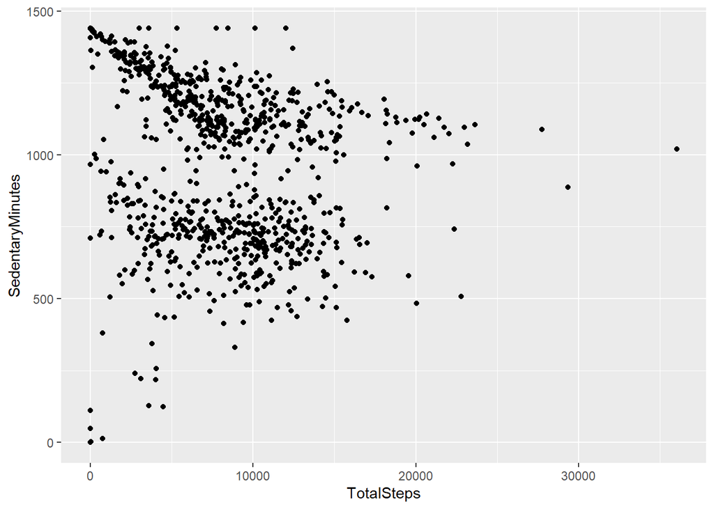

```r
ggplot(data=dailyact, aes(x=TotalSteps, y=SedentaryMinutes)) + geom_point()
```

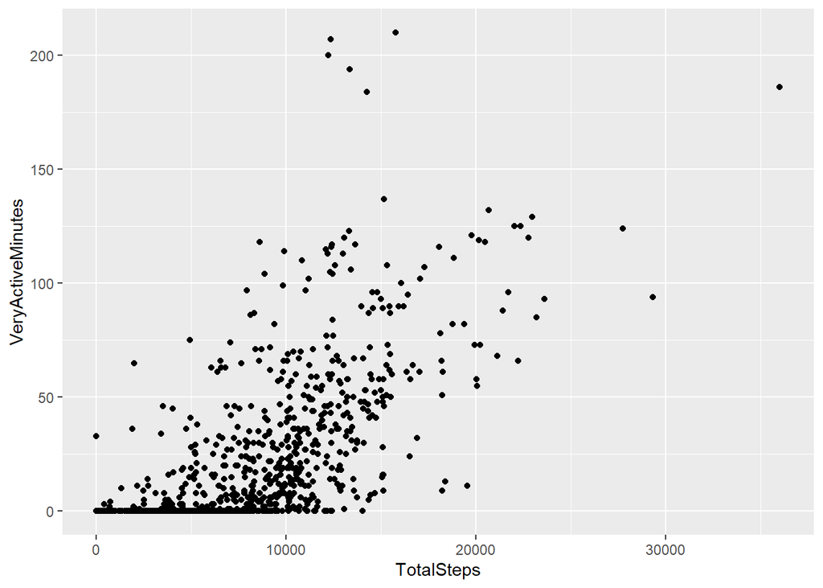

```r
ggplot(data=dailyact, aes(x=TotalSteps, y=VeryActiveMinutes)) + geom_point()
```

```r
cor(dailyact$TotalSteps,dailyact$VeryActiveMinutes)
```

```
## [1] 0.6670787
```

We can see here that there is a correlation between how having more VeryActiveMinutes a participant had, the more Total Steps they had.

2.Is there a correlation between then number of minutes someone sleeps and their steps taken in a day.

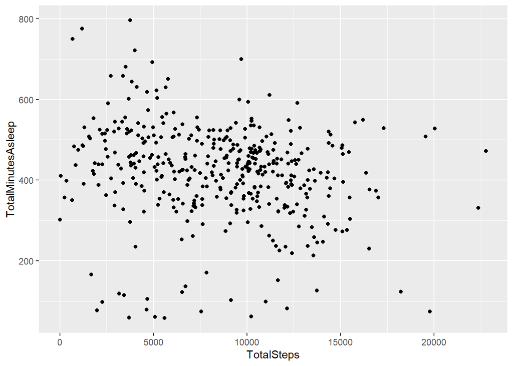

```r
# The first thing we had to do was inner join the dailyact and sleep datasets. I called this new datset z.

z<-merge(dailyact,sleepday, by.x = c("Id","Date"), by.y = c("Id","Date"))

ggplot(data=z, aes(x=TotalSteps, y=TotalMinutesAsleep)) + geom_point()
```

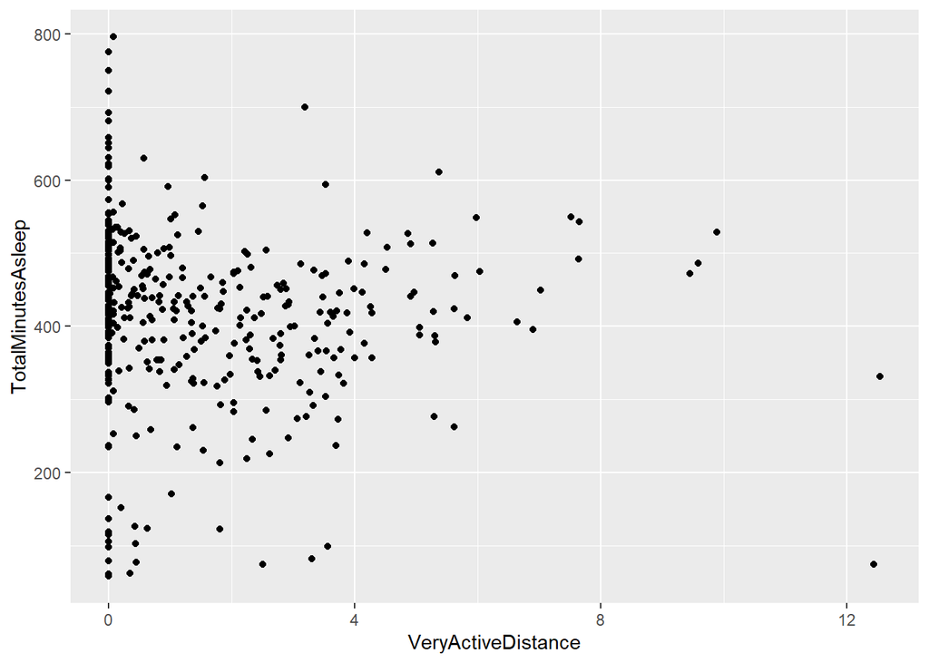

```r
ggplot(data=z, aes(x=VeryActiveDistance, y=TotalMinutesAsleep)) + geom_point()
```

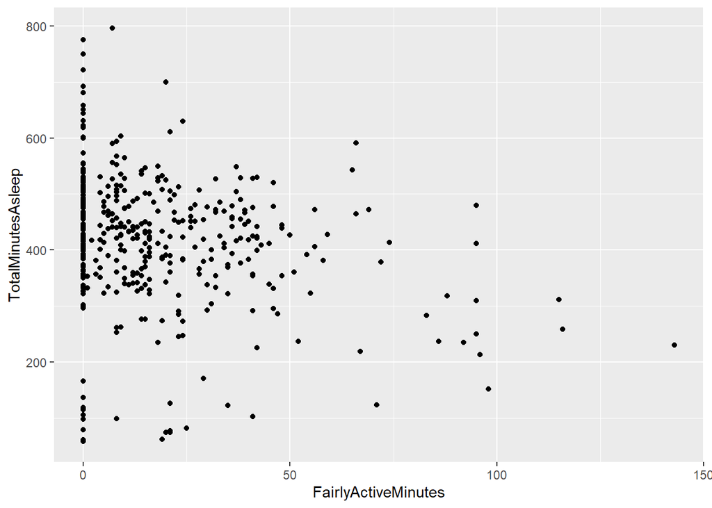

```r
ggplot(data=z, aes(x=FairlyActiveMinutes, y=TotalMinutesAsleep)) + geom_point()
```

There does not seem to be a correlation between the amount of sleep you get versus how active or non active you are. It also doesn’t seem like there is much of a correlation on sleep and how active you are,

3.Which day of the week are people most active?

```r
dailyact2<-dailyact
dailyact2$weekday<-weekdays(dailyact2$Date)

dailyact2  %>%  group_by(weekday) %>% summarise(mean(TotalSteps));
```

```
## # A tibble: 7 x 2
##   weekday   `mean(TotalSteps)`
##   <chr>                  <dbl>
## 1 Friday                 7448.
## 2 Monday                 7781.
## 3 Saturday               8153.
## 4 Sunday                 6933.
## 5 Thursday               7406.
## 6 Tuesday                8125.
## 7 Wednesday              7559.
```

```
## No summary function supplied, defaulting to `mean_se()`
```

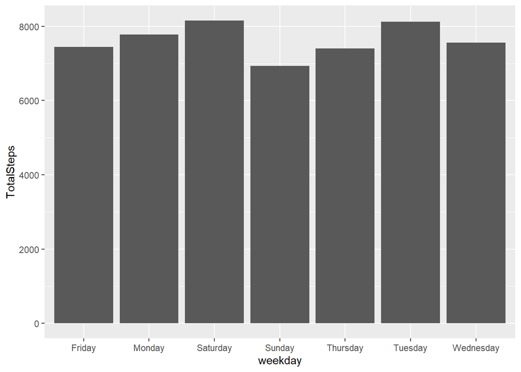

```r
ggplot(data=dailyact2,aes(x=weekday , y=TotalSteps))+geom_bar(stat="summary")
```

## Recommendations

1. I would like Bellabeat to make sure that as soon as people start using a device, they should set up the steps, calories, and sleep functions. Thoes are the most tracked statistics.
2. Defining what a healthy weight for a women, or anyone, can vary. Therefore it made sense as to why most women did not track theier weigh. However, for women who do want to gain or lose weight, they should still keep that feature in their. When setting up Bellabeat smart devices, Bellabeat should ask the women if they want their weight tracked.For toes who say no, they should not feel inclined to use that portion of the device. But for women that say yes, the women should then be allowed to tell the smart device what their goal is.
3. If a person is below a certain amount of steps for a certain day, the Bellabeat smart device should set up a reminder that tells the user to be more active to at least get close to the average step count for a day.
4. Bellabeat should encourage users to pick 3-4 days to be more active and then give that person reminders on those days to do something active.
5. The bellabeat adevices should give a person a reminder to go to sleep if the user chooses to set a time they would like to go to sleep.

## Limitations to the Study

There was only 33 participants. Although this does comply with the central limit theorem to make our data approximately a normal distribution, We may want to find more data in order to get an ever better picture of how people use smart health. technology.